# weatherapi-vignette

This package wraps the Weather API, available from: weatherapi.com. The Weather API provides access to real-time and historical weather info, astronomy, time zone, and sports data.

## Setup

This package relies on the API key provided by the Weather API. To get started on using this package, please follow these steps:

1. Sign-up for an account here: https://www.weatherapi.com/signup.aspx
2. Go to your “my account” page and copy your API key
3. Open RStudio and set your API key in the .Renviron file
4. You can do this by running the following code in your R console  
   `usethis::edit_r_environ()`
5. Then add this line inside the .Renviron file  
   `API_KEY = <your_api_key>`
6. Save and close the .Renviron file and you are good to go!

## Error Codes

This table provides descriptions of the possible error codes.

| Error Code | Description |
| --- | --- |
| 400 | Invalid/missing location argument or internal server error |
| 401 | Invalid/missing API key |
| 403 | API Key disabled or has reached maximum calls quota |

## Functions

### 1. Set API Key

This function can be used to see the API key that you have set during the setup step above. To see if you have entered your API key correctly, you can run `api_key()` and it will output the API key that you have set in the .Renviron file.

This function can also be used as another way to set the API key. Note that this will not change the value of the API key in the .Renviron file, but it will change the API key being used when calling the functions. To set a temporary API key, you can run `api_key(force=TRUE)` which will require you to enter your API key in the interactive console. Enter your API key in the R console and press enter. You have now changed the API key that will be used by the functions (but not in the .Renviron file).

#### Usage

`api_key(force=FALSE)`

#### Arguments

`force` : A boolean to force-set new API key for current environment. This is done to force-set a new API key to TRUE, the default value is FALSE.

#### Value

A vector containing the API key

#### Examples

`api_key()` # To display API key that was set in the .Renviron file  
`api_key(force=TRUE)` # To change the API key

### 2. Get Current Weather

#### Usage

`get_current_weather(location, aqi="yes")`

#### Value

A data frame of current weather information

#### Examples

`get_current_weather("Kelowna")`  
`get_current_weather(c("Kelowna", "Vancouver"), "no")`

This function is used to get the current real-time weather information of a specified location. Air quality information of that location is included by default and can be omitted by setting `aqi="no"`. The resulting information will be a data frame.

For instance, if you want to get the current real-time weather condition for Kelowna, you can use:

```r
get_current_weather("Kelowna")
```

```
#>   location.name  location.region location.country location.lat location.lon
#> 1       Kelowna British Columbia           Canada         49.9      -119.48
#>      location.tz_id location.localtime_epoch location.localtime
#> 1 America/Vancouver               1645232611   2022-02-18 17:03
#>   current.last_updated_epoch current.last_updated current.temp_c current.temp_f
#> 1                 1645231500     2022-02-18 16:45            1.9           35.4
#>   current.is_day current.condition.text
#> 1              1          Partly cloudy
#>                           current.condition.icon current.condition.code
#> 1 //cdn.weatherapi.com/weather/64x64/day/116.png                   1003
#>   current.wind_mph current.wind_kph current.wind_degree current.wind_dir
#> 1              1.1              1.8                 152              SSE
#>   current.pressure_mb current.pressure_in current.precip_mm current.precip_in
#> 1                1024               30.25                 0                 0
#>   current.humidity current.cloud current.feelslike_c current.feelslike_f
#> 1               87            48                 1.9                35.4
#>   current.vis_km current.vis_miles current.uv current.gust_mph current.gust_kph
#> 1             10                 6          2              1.8              2.9
#>   current.air_quality.co current.air_quality.no2 current.air_quality.o3
#> 1                    257                     2.4                   60.1
#>   current.air_quality.so2 current.air_quality.pm2_5 current.air_quality.pm10
#> 1                     0.5                       0.8                      1.2
#>   current.air_quality.us.epa.index current.air_quality.gb.defra.index
#> 1                                1                                  1
```

If you want to get a list of current real-time weather condition for Kelowna, Vancouver, and Toronto, you can use:

```r
cities <- c("Kelowna", "Vancouver", "Toronto")
get_current_weather(cities)
```

```
#>   location.name  location.region location.country location.lat location.lon
#> 1       Kelowna British Columbia           Canada        49.90      -119.48
#> 2     Vancouver British Columbia           Canada        49.25      -123.13
#> 3       Toronto          Ontario           Canada        43.67       -79.42
#>      location.tz_id location.localtime_epoch location.localtime
#> 1 America/Vancouver               1645232611   2022-02-18 17:03
#> 2 America/Vancouver               1645232611   2022-02-18 17:03
#> 3   America/Toronto               1645232611   2022-02-18 20:03
#>   current.last_updated_epoch current.last_updated current.temp_c current.temp_f
#> 1                 1645231500     2022-02-18 16:45            1.9           35.4
#> 2                 1645231500     2022-02-18 16:45            8.0           46.4
#> 3                 1645228800     2022-02-18 19:00           -8.4           16.9
#>   current.is_day current.condition.text
#> 1              1          Partly cloudy
#> 2              1          Partly cloudy
```

[output cut: 33 more lines]

#### Variable description

The table below summarizes the data type and the descriptions of the returned variables in the dataframe.

[output not shown]

### 3. Get Time Zone

#### Usage

`get_time_zone(location)`

#### Arguments

`location` : A vector of location

#### Value

A data frame of local time-zone information

#### Examples

`get_time_zone("Kelowna")` `get_time_zone(c("Kelowna", "Vancouver"))`

This function is used to get the time zone and local time information of a specified location. The resulting information will be a data frame.

For instance, if you want to get the time zone and local time information of Kelowna, you can use:

```r
get_time_zone("Kelowna")
```

```
#>   location.name  location.region location.country location.lat location.lon
#> 1       Kelowna British Columbia           Canada         49.9      -119.48
#>      location.tz_id location.localtime_epoch location.localtime
#> 1 America/Vancouver               1645232611   2022-02-18 17:03
```

If you want to get the time zone and local time information of multiple locations, you can use:

```r
cities <- c("Kelowna","Vancouver","Toronto")
get_time_zone(cities)
```

```
#>   location.name  location.region location.country location.lat location.lon
#> 1       Kelowna British Columbia           Canada        49.90      -119.48
#> 2     Vancouver British Columbia           Canada        49.25      -123.13
#> 3       Toronto          Ontario           Canada        43.67       -79.42
#>      location.tz_id location.localtime_epoch location.localtime
#> 1 America/Vancouver               1645232611   2022-02-18 17:03
#> 2 America/Vancouver               1645232612   2022-02-18 17:03
#> 3   America/Toronto               1645232612   2022-02-18 20:03
```

#### Variable description

The table below summarize the data type and the descriptions of the returned variables in the dataframe.

| Variable | Type | Description |
| --- | --- | --- |
| location.name | chr | Name of the requested location |
| location.region | chr | Name of the location region |
| location.country | chr | Name of the location country |
| location.lat | num | Latitude in decimal degree |
| location.lon | num | Longitude in decimal degree |
| location.tz_id | chr | Time zone id |
| location.localtime_epoch | int | Local time in epoch |
| location.localtime | chr | Local time in yyyy-MM-dd HH:mm format |

### 4. Get Sports Events

#### Usage

`get_sports_events(location, sport)`

#### Arguments

`location` : A vector of location `sport` : A string of sport type (“football”,“cricket”,“golf”)

#### Value

A data frame of upcoming sports events in a location

#### Examples

`get_sports_events("London", "football")` `get_sports_events(c("London", "Oxford"))`

This function is used to get a list of all upcoming sports events (football, cricket, golf) in a specified location. The resulting information will be a data frame.

For instance, if you want to get a list of all upcoming sports events (football, cricket, golf) in London, you can use:

```r
get_sports_events("London", "football")
```

```
#>          football.stadium football.country football.region  football.tournament
#> 1         West Ham United   United Kingdom                       Premier League
#> 2               Fulham Fc   United Kingdom                 Sky Bet Championship
#> 3     Northampton Town Fc   United Kingdom                   Sky Bet League Two
#> 4                 Arsenal   United Kingdom                       Premier League
#> 5             Aston Villa   United Kingdom                       Premier League
#> 6  Brighton & Hove Albion   United Kingdom                       Premier League
#> 7          Crystal Palace   United Kingdom                       Premier League
#> 8               Liverpool   United Kingdom                       Premier League
#> 9          Southampton Fc   United Kingdom                       Premier League
#> 10       Blackburn Rovers   United Kingdom                 Sky Bet Championship
#>      football.start                        football.match
#> 1  2022-02-19 12:30   West Ham United vs Newcastle United
#> 2  2022-02-19 12:30           Fulham vs Huddersfield Town
#> 3  2022-02-19 14:00 Northampton Town vs Colchester United
#> 4  2022-02-19 15:00                  Arsenal vs Brentford
#> 5  2022-02-19 15:00                Aston Villa vs Watford
#> 6  2022-02-19 15:00   Brighton and Hove Albion vs Burnley
#> 7  2022-02-19 15:00             Crystal Palace vs Chelsea
#> 8  2022-02-19 15:00             Liverpool vs Norwich City
#> 9  2022-02-19 15:00                Southampton vs Everton
#> 10 2022-02-19 15:00          Blackburn Rovers vs Millwall
```

#### Variable description

The table below summarizes the data type and the descriptions of the returned variables in the dataframe.

| Variable | Type | Description |
| --- | --- | --- |
| football.stadium | chr | Name of stadium |
| football.country | chr | Country |
| football.region | chr | Region |
| football.tournament | chr | Tournament name |
| football.start | chr | Start local date and time for event in yyyy-MM-dd HH:mm format |
| football.match | chr | Match name |

### 5. Send request

#### Introduction

This is a helper function to send a request to retrieve data from weatherapi.com.

#### Usage

`data_request(query)`

#### Arguments

`query`: A list that contains information of city, date, and api_key, represented by `q`, `dt`, and `key`, respectively.

#### Value

A HTTP response.

#### Examples

`data_request(list(key="9d56997213e54667a41172101221602", q="Shanghai",dt="2022/01/01"))`

### 6. Get Astronomy Data

#### Introduction

This function is an API wrapper to retrieve astronomy data from weatherapi.com. Given a desired city and date, the wrapper will return astronomy data such as sunset time and moon rise time. Error messages are given when a user enters invalid input. A helper function is used for sending request.

#### Usage

`get_astronomy(city, date)`

#### Arguments

`city` : A string indicating city (e.g., “London”, “Beijing”).  
`date`: A string of the form yyyy-mm-dd indicating date (e.g., “2022-02-10”).

#### Value

A dataframe with the columns `sunrise`, `sunset`, `moonrise`, `moonset`, `moon_phase`, and `moon_illumination`.

#### Examples

`get_astronomy("Beijing", "2022-01-10")`  
`get_astronomy("Kelowna", "2021-06-06")`

### 7. Get History Astronomical Weather

#### Usage

`get_history_astro_information(key,q,dt)`

#### Arguments

`key` : A string containing the API key  
`q` : A string containing the location, which can be an US Zipcode, UK Postcode, Canadian Postalcode, IP address, Latitude/Longitude (decimal degree) or city name.  
`dt` : A string containing the date of query, which should be within the last 7 days.

#### Value

A data frame containing the astronomical information for the day.

#### Examples

`get_history_astro_information("YourAPIKeyHere","London","2022-02-12")`  
`get_history_astro_information("YourAPIKeyHere","Beijing","2022-02-14")`

#### Variable description

The table below summarizes the data type and the descriptions of the returned variables in the dataframe.

| Variable | Type | Description |
| --- | --- | --- |
| sunrise | chr | The sunrise time |
| sunset | chr | The sunset time |
| moonrise | chr | The moonrise time |
| moonset | chr | The moonset time |
| moon_phase | chr | The moon phase |
| moon_illumination | chr | The illumination of the moon |

### 8. Get History Daily Weather

#### Usage

`get_history_daily_weather(key,q,dt)`

#### Arguments

`key` : A string containing the API key  
`q` : A string containing the location, which can be an US Zipcode, UK Postcode, Canadaian Postalcode, IP address, Latitude/Longitude (decimal degree) or city name.  
`dt` : A string containing the date of query, which should be within the last 7 days.

#### Value

A data frame containing the daily weather information of the day.

#### Examples

`get_history_daily_weather("YourAPIKeyHere","London","2022-02-12")`  
`get_history_daily_weather("YourAPIKeyHere","Beijing","2022-02-14")`

#### Variable description

The table below summarizes the data type and the descriptions of the returned variables in the dataframe.

| Variable | Type | Description |
| --- | --- | --- |
| maxtemp_c | num | Daily max temperature (Celsius) |
| maxtemp_f | num | Daily max temperature (Fahrenheit) |
| mintemp_c | num | Daily min temperature (Celsius) |
| mintemp_f | num | Daily min temperature (Fahrenheit) |
| avgtemp_c | num | Daily average temperature (Celsius) |
| avgtemp_f | num | Daily average temperature (Fahrenheit) |
| maxwind | num | Daily max wind speed (miles per hour) |
| maxwind_kph | num | Daily max wind speed (kilometers per Hour) |
| totalprecip_mm | num | Daily total Precipitation(mm) |
| totalprecip_in | num | Daily total Precipitation(in) |
| avgvis_km | num | Daily average visibility in kilometers |
| avgvis_miles | num | Daily average visibility in miles |
| avghumidity | num | Daily average humidity |
| condition.text | chr | Weather condition text |
| condition.icon | chr | Weather icon url |
| condition.code | num | Weather condition unique code |
| uv | num | UV Index |

### 9. Get History Hourly Weather

#### Usage

`get_history_hourly_weather(key,q,dt,h)`

#### Arguments

`key` : A string containing the API key  
`q` : A string containing the location, which can be an US Zipcode, UK Postcode, Canadian Postalcode, IP address, Latitude/Longitude (decimal degree) or city name.  
`dt` : A string containing the date of query, which should be within the last 7 days.  
`h` : An integer containing the hour of query, which be in the range of 0 to 23.

#### Value

A data frame containing the daily weather information of the hour in the day.

#### Examples

`get_history_hourly_weather("YourAPIKeyHere","London","2022-02-12",4)`get_history_daily_weather(“YourAPIKeyHere”,“Beijing”,“2022-02-14”,23)

#### Variable description

The table below summarizes the data type and the descriptions of the returned variables in the dataframe.

[output not shown]

## Plotting using the weatherapi package

### 1. Plot the current temperature and feels-like temperature for different locations

The following exercise shows how to get current temperature and feels-like temperature data using the get_current_weather() function and plots it as a line chart.

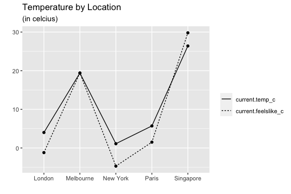

```r
library(ggplot2)
library(reshape2)

# Get current weather data
loc <- c("London", "New York", "Paris", "Melbourne", "Singapore")
data <- get_current_weather(loc,"no")

# Get temperature info and melt dataframe
data <- data[c("location.name", "current.temp_c", "current.feelslike_c")]
data <- melt(data)

# Plot temperature
ggplot(data=data, aes(x=location.name, y=value, group=variable, linetype=variable)) +
  geom_line()+
  geom_point()+
  labs(title="Temperature by Location", subtitle="(in celcius)", x="", y="", linetype="")
```

### 2. Plot local time zone of different locations in world-map

The following exercise shows how to extract the time-zone of different locations and plot it in a world map.

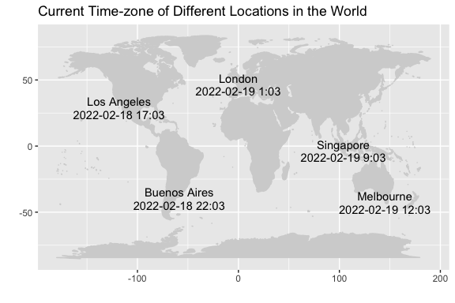

```r
# Get local time zone data
loc <- c("London", "Los Angeles", "Buenos Aires", "Melbourne", "Singapore")
data <- get_time_zone(loc)

# Get the world map coordinates
library(tidyverse)
world <- map_data("world")

# Plot time zone of different location in world map
ggplot() +
  geom_map(
    data = world, map = world,
    aes(long, lat, map_id = region),
    color = "lightgray", fill = "lightgray") +
  geom_text(data=data,
            aes(location.lon, location.lat, label=location.name)) +
  geom_text(data=data,
            aes(location.lon, location.lat, label=location.localtime),nudge_y = -10) +
  labs(title="Current Time-zone of Different Locations in the World", x="", y="")
```

### 3. Plot the max and min temperature in Celsius in the past 7 days

The following exercise will show how to get min and max temperature in the past 7 days using the get_history_daily_weather() function and plot it as a line chart.

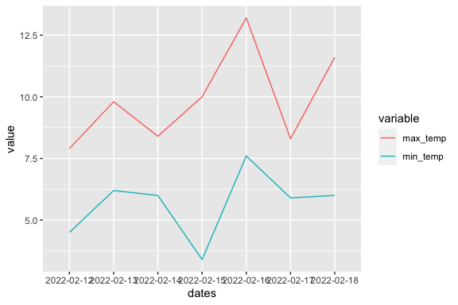

```r
library(ggplot2)
library(reshape2)
min_temp<- vector()
max_temp<- vector()

td <- Sys.Date()
dates <- c()
for (i in  6:0){
  dates <- c(dates, as.character(td-i))
}

for(i in seq_along(dates)){
  max_temp<-append(max_temp,get_history_daily_weather("London",dates[i])$maxtemp_c)
  min_temp<-append(min_temp,get_history_daily_weather("London",dates[i])$mintemp_c)
}
df <- data.frame(dates,max_temp, min_temp)
mdf <- melt(df,id.vars="dates")
ggplot(mdf, aes(x=dates, y=value, colour=variable, group=variable )) +
geom_line()
```

### 4. Plot the 24 hour temperature in Celsius for a specific day

The following exercise shows how to get hourly temperature in a day using the get_history_hourly_weather() function and plot it as a line chart.

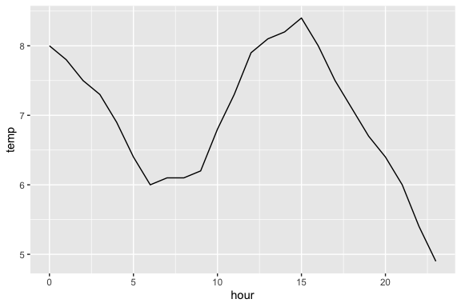

```r
library(ggplot2)
library(reshape2)
temp<- vector()
hour<-0:23
for(i in seq_along(hour)){
  temp<-append(temp,get_history_hourly_weather("London","2022-02-14",hour[i])$temp_c)
}
df <- data.frame(hour,temp)
ggplot(df, aes(x=hour, y=temp)) +
  geom_line()
```

### 5. Plot the moon_illumination at Beijing on same date of different years

The code below describes how to get the moon_illumination at Beijing on same date from year 2011 to year 2021 using the `get_astronomy` function and plot the result.

[figure not shown]

```r
library(ggplot2)

years <- c()
moon_illuminations <- c()

for (i in 2011:2021){
  year <- as.character(i)
  date <- paste(year, "-06-06", sep="")

  # get astronomy data on desired date at Beijing
  data <- get_astronomy("Beijing", date)

  # extract moon_illumination
  moon_illumination <- data$moon_illumination

  years <- c(years, year)
  moon_illuminations <- c(moon_illuminations, moon_illumination)
}

result <- data.frame(year=years, moon_illumination=moon_illuminations)


# Plot moon_illumination
ggplot(data=result, aes(x=year, y=moon_illumination, group=1)) +
  geom_line()+
  labs(title="Moon illumination at Beijing on July 6th", x="", y="", linetype="")
```